# Η κανονική κατανομή σε διάστημα

Συνοδευτικό του «Μέσος όρος και απόκλιση με ολοκληρώματα»

Συγγραφέας

[Kostas Maistrelis](https://maistrelis.com)

Δημοσιευμένο

28 Σεπτεμβρίου 2026

Στο κυρίως κείμενο υπολογίσαμε μέσο όρο, μέση απόλυτη απόκλιση και διακύμανση για την τυπική κανονική $N(0, 1)$ σε όλο τον άξονα. Εδώ περιορίζουμε την ίδια καμπύλη **σε ένα μόνο τμήμα** του άξονα, το $[a, b] = [-0.5,\ 2]$. Αυτό εισάγει μια νέα έννοια, την **κανονικοποίηση**, και δίνει μια κατανομή που **δεν είναι συμμετρική**. Έτσι φαίνονται πράγματα που στη συμμετρική κανονική κρύβονται.

## Κανονικοποίηση

Το συνολικό βάρος μιας πυκνότητας πρέπει να είναι 1. Αν κρατήσουμε την καμπύλη μόνο στο $[a, b]$, το εμβαδόν της εκεί είναι **μικρότερο** από 1:

$$Z = \int_a^b f(x)\,dx < 1$$

Για να πάρουμε έγκυρη πυκνότητα, **διαιρούμε με το $Z$**. Όλα τα βάρη μεγαλώνουν αναλογικά, ώστε το συνολικό βάρος να είναι ξανά 1:

$$g(x) = \frac{f(x)}{Z}, \qquad \int_a^b g(x)\,dx = 1$$

Είναι η ίδια ιδέα με το $\frac{1}{b-a}$ των απλών συναρτήσεων. Κι εκεί διαιρούσαμε με το «συνολικό μέγεθος», ώστε το συνολικό βάρος να είναι 1.

**Κώδικας**

```r
f <- function(x) (1 / sqrt(2 * pi)) * exp(-x^2 / 2)
a <- -0.5
b <- 2

Z <- integrate(f, a, b)$value
g <- function(x) f(x) / Z

c(Z = Z, `∫ g` = integrate(g, a, b)$value)
```

```
        Z       ∫ g
0.6687123 1.0000000
```

Από εδώ και πέρα όλοι οι τύποι του κυρίως κειμένου ισχύουν όπως είναι, με $g$ στη θέση της $f$ και τα όρια $a, b$ στη θέση των $\pm\infty$.

## Μέσος όρος

$$\mu = \int_a^b x \cdot g(x)\,dx$$

**Κώδικας**

```r
mu <- integrate(function(x) x * g(x), a, b)$value
mu
```

```
[1] 0.4457438
```

Ο μέσος όρος **δεν είναι πια 0**. Η καμπύλη κόβεται στο $-0.5$ αριστερά αλλά απλώνεται ως το 2 δεξιά, οπότε το σημείο ισορροπίας μετακινείται δεξιά. Για το πώς συγκρίνεται με τον διάμεσο, δες το συνοδευτικό κείμενο για τον διάμεσο.

## Μέση απόλυτη απόκλιση

$$\text{ΜΑΑ} = \int_a^b |x - \mu| \cdot g(x)\,dx$$

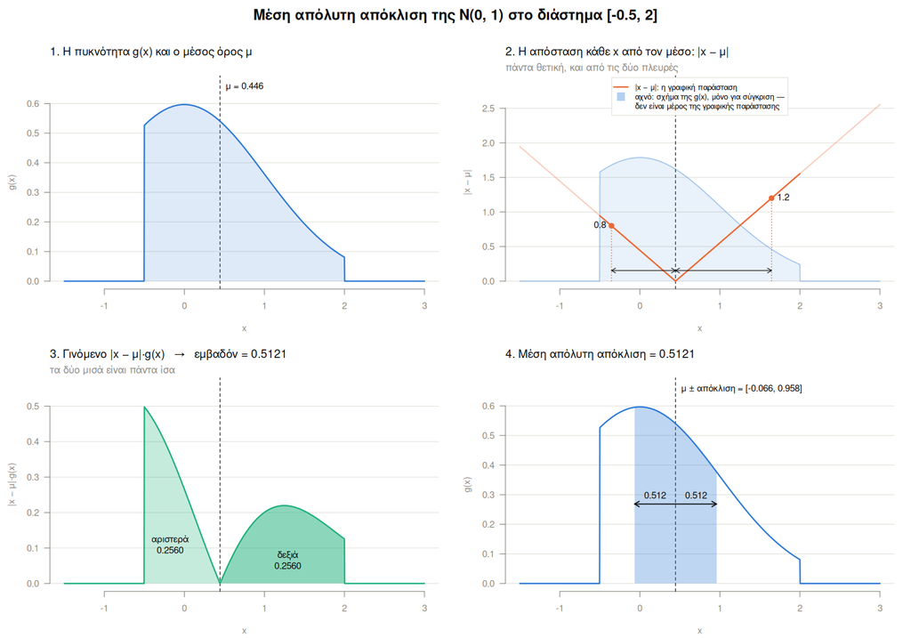

Εικόνα 1: Μέση απόλυτη απόκλιση της $N(0, 1)$ στο $[-0.5, 2]$. (`mad_visual.R`)

**Κώδικας**

```r
mad <- integrate(function(x) abs(x - mu) * g(x), a, b, rel.tol = 1e-10)$value
mad
```

```
[1] 0.5120563
```

Στην Εικόνα 1, σε σύγκριση με την πλήρη κανονική του κυρίως κειμένου:

- Στο **βήμα 1** η καμπύλη έχει «σκαλοπάτια» στα άκρα $a$ και $b$. Εκεί κόβεται, και είναι ψηλότερη από την αρχική, λόγω της διαίρεσης με το $Z$.
- Στο **βήμα 2** το «V» είναι αχνό έξω από το $[a, b]$. Εκεί το βάρος είναι 0, οπότε αυτές οι αποστάσεις δεν μετράνε.
- Στο **βήμα 3** τα δύο πράσινα κομμάτια έχουν **εντελώς διαφορετικό σχήμα**: ένα ψηλό και στενό αριστερά, ένα χαμηλό και φαρδύ δεξιά. Έχουν όμως **ίσο εμβαδόν**. Η ιδιότητα ισορροπίας του μέσου όρου ισχύει για κάθε κατανομή, όχι μόνο για τις συμμετρικές.
- Στο **βήμα 4** η απόκλιση ($\approx 0.512$) είναι μικρότερη από της πλήρους κανονικής ($\approx 0.798$). Οι τιμές περιορίζονται σε στενότερο διάστημα.

## Διακύμανση

$$\sigma^2 = \int_a^b (x - \mu)^2 \cdot g(x)\,dx$$

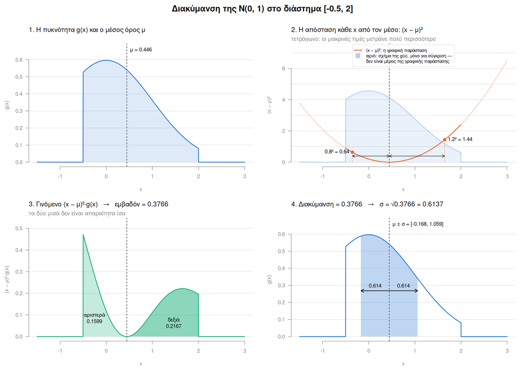

Εικόνα 2: Διακύμανση της $N(0, 1)$ στο $[-0.5, 2]$. (`mad_visual.R`)

**Κώδικας**

```r
left  <- integrate(function(x) (x - mu)^2 * g(x), a, mu)$value
right <- integrate(function(x) (x - mu)^2 * g(x), mu, b)$value
c(`αριστερά` = left, `δεξιά` = right, `διακύμανση` = left + right,
  `σ` = sqrt(left + right))
```

```
  αριστερά      δεξιά διακύμανση          σ
 0.1598941  0.2166998  0.3765938  0.6136724
```

Εδώ φαίνεται μια σημαντική διαφορά από την απόλυτη απόκλιση. Στο **βήμα 3** της Εικόνα 2 τα δύο μισά **δεν είναι ίσα** (αριστερά $\approx 0.16$, δεξιά $\approx 0.217$). Ο μέσος όρος ισορροπεί τις **απλές** αποστάσεις, όχι τα **τετράγωνά** τους. Η δεξιά πλευρά φτάνει πιο μακριά από το $\mu$, και το τετράγωνο «φουσκώνει» αυτές τις μακρινές αποστάσεις. Στην πλήρη κανονική τα μισά ήταν ίσα μόνο χάρη στη συμμετρία.

## Επαλήθευση με κλειστούς τύπους

Για την κανονική σε διάστημα υπάρχουν γνωστοί κλειστοί τύποι, με $\varphi$ = `dnorm` και $\Phi$ = `pnorm`. Τα ολοκληρώματα συμφωνούν μαζί τους:

**Κώδικας**

```r
Zc   <- pnorm(b) - pnorm(a)
mu_c <- (dnorm(a) - dnorm(b)) / Zc
var_c <- 1 + (a * dnorm(a) - b * dnorm(b)) / Zc - mu_c^2
mad_c <- 2 * (mu_c * (pnorm(mu_c) - pnorm(a)) - (dnorm(a) - dnorm(mu_c))) / Zc

rbind(`ολοκληρώματα` = c(mu, mad, left + right),
      `κλειστοί τύποι` = c(mu_c, mad_c, var_c)) |>
  `colnames<-`(c("μέσος", "απόλ. απόκλιση", "διακύμανση"))
```

```
                   μέσος απόλ. απόκλιση διακύμανση
ολοκληρώματα   0.4457438      0.5120563  0.3765938
κλειστοί τύποι 0.4457438      0.5120563  0.3765938
```

## Ασκήσεις

**1.** Χωρίς να υπολογίσεις ολοκλήρωμα: ποιος είναι ο μέσος όρος της κανονικής στο $[-1, 1]$; Μετά υπολόγισε το $Z$. Τι σημαίνει ο αριθμός που βγαίνει;

**ΣυμβουλήΛύση**

Ο μέσος είναι **0**, γιατί το διάστημα είναι συμμετρικό γύρω από το 0 και η καμπύλη επίσης. Το $Z = \int_{-1}^{1} f(x)\,dx \approx 0.683$ είναι το ποσοστό του βάρους της κανονικής μέσα στο $\mu \pm \sigma$, το γνωστό «68%».

**2.** Υπολόγισε τον μέσο όρο της κανονικής στο $[0, \infty)$ (τη «μισή» κανονική). Σύγκρινέ τον με τη μέση απόλυτη απόκλιση της πλήρους $N(0, 1)$ από το κυρίως κείμενο. Γιατί βγαίνουν ίσα;

**ΣυμβουλήΛύση**

Εδώ $Z = 0.5$ και $g(x) = 2 f(x)$, οπότε

$$\mu = \int_0^\infty x \cdot 2 f(x)\,dx = \sqrt{2/\pi} \approx 0.798$$

Είναι ακριβώς η μέση απόλυτη απόκλιση της $N(0, 1)$. Ο λόγος είναι ότι $\int |x| f(x)\,dx = 2 \int_0^\infty x f(x)\,dx$, επειδή η $|x| f(x)$ είναι συμμετρική. Η μέση απόσταση από το 0 σε όλη την κανονική είναι η ίδια με τον μέσο όρο του θετικού μισού.

**Κώδικας**

```r
c(`μισή κανονική` = integrate(function(x) x * 2 * f(x), 0, Inf)$value,
  `√(2/π)` = sqrt(2 / pi))
```

```
μισή κανονική        √(2/π)
    0.7978846     0.7978846
```

## Συντελεστές

Συγγραφή: [Kostas Maistrelis](https://maistrelis.com) (ORCID 0000-0002-0851-2866). Το κείμενο, οι εικόνες και ο κώδικας R αναπτύχθηκαν σε συνεργασία με το [Claude](https://www.anthropic.com/claude) της Anthropic.

Γλωσσική επιμέλεια: [Codex](https://openai.com/codex/) της OpenAI.

## Άδεια χρήσης

Το κείμενο και οι εικόνες διατίθενται με την άδεια [Creative Commons Αναφορά Δημιουργού 4.0 (CC BY 4.0)](https://creativecommons.org/licenses/by/4.0/deed.el): μπορείς να τα χρησιμοποιήσεις, να τα αλλάξεις και να τα μοιραστείς, αρκεί να αναφέρεις την πηγή. Ο κώδικας (τα scripts R, το Makefile και τα κομμάτια κώδικα του κειμένου) διατίθεται με την άδεια [MIT](https://opensource.org/license/mit).